# Week 2 Exercises

Henrik Husberg

# Exercise 1

#### 1.1

Create a new code chunk where you load the tidyverse package. In the chunk settings, suppress any output messages.

#### 1.2

```r
df
```

| group | gender | score1 | score2 |
| --- | --- | --- | --- |
| 2 | F | 18.66590 | 14.7563711082321 |
| 1 | M | 20.12620 | 15.1463059324341 |
| 2 | F | 17.39163 | 19.0025387614538 |
| 1 | M | 18.74004 | 15.5693261509451 |
| 2 | F | 18.53420 | 16.7322250273729 |
| 1 | 999 | 16.91496 | 16.4511010915052 |
| 2 | M | 20.41574 | 15.1008590050657 |
| 1 | F | 20.32081 | 15.191041952879 |
| 1 | F | 19.40043 | 13.9717194882152 |
| 2 | M | 21.17367 | 22.6918520246433 |

[output cut: 50 more lines]

There is something to fix in three of the variables. Explore the data and describe what needs to be corrected.

**Hint**: You can use e.g. str(), distinct(), and summary() to explore the data.

```r
## Henrik: Here I'll take a look at the structure of the data to see if I can spot any oddities:
str(df)
```

```
## tibble [60 x 4] (S3: tbl_df/tbl/data.frame)
##  $ group : int [1:60] 2 1 2 1 2 1 2 1 1 2 ...
##  $ gender: chr [1:60] "F" "M" "F" "M" ...
##  $ score1: num [1:60] 18.7 20.1 17.4 18.7 18.5 ...
##  $ score2: chr [1:60] "14.7563711082321" "15.1463059324341" "19.0025387614538" "15.5693261509451" ...
```

```r
summary(df)
```

```
##      group        gender              score1         score2
##  Min.   :1.0   Length:60          Min.   :14.17   Length:60
##  1st Qu.:1.0   Class :character   1st Qu.:16.85   Class :character
##  Median :1.5   Mode  :character   Median :17.61   Mode  :character
##  Mean   :1.5                      Mean   :17.89
##  3rd Qu.:2.0                      3rd Qu.:19.01
##  Max.   :2.0                      Max.   :21.53
```

```r
distinct(df, group)
```

| group |
| --- |
| 2 |
| 1 |

```r
distinct(df, gender)
```

| gender |
| --- |
| F |
| M |
| 999 |

Henrik: Looking at the data, we see that the variable score2 seems to be coded as a string, not numerical. So we need to convert score2 to numerical data. In the gender variable we have some apparently missing data coded as 999, we will convert those to NA:s. Also, the gender variable should be coded as a factor.

# Exercise 2

#### 2.1

Make the corrections you described above.

```r
##Alt: df <- transform(df, score2 = as.numeric(score2))
df <- df %>%
  mutate(score2 = as.numeric(score2)) %>%
  mutate(gender = na_if(gender, 999)) %>%
  mutate(gender = as.factor(gender))

summary(df)
```

```
##      group      gender       score1          score2
##  Min.   :1.0   F   :28   Min.   :14.17   Min.   :11.28
##  1st Qu.:1.0   M   :28   1st Qu.:16.85   1st Qu.:14.44
##  Median :1.5   NA's: 4   Median :17.61   Median :15.47
##  Mean   :1.5             Mean   :17.89   Mean   :16.08
##  3rd Qu.:2.0             3rd Qu.:19.01   3rd Qu.:17.82
##  Max.   :2.0             Max.   :21.53   Max.   :22.69
```

```r
str(df)
```

```
## tibble [60 x 4] (S3: tbl_df/tbl/data.frame)
##  $ group : int [1:60] 2 1 2 1 2 1 2 1 1 2 ...
##  $ gender: Factor w/ 2 levels "F","M": 1 2 1 2 1 NA 2 1 1 2 ...
##  $ score1: num [1:60] 18.7 20.1 17.4 18.7 18.5 ...
##  $ score2: num [1:60] 14.8 15.1 19 15.6 16.7 ...
```

Henrik: Now the variable score2 is coded as numerical data, group as integer, gender as a factor with two leves and missing values as NA and we can use the data in our further analyses.

#### 2.2

Count observations by group and gender. Arrange by the number of observations (ascending).

```r
df %>%
  count(group, gender) %>%
  arrange(n)
```

| group | gender | n |
| --- | --- | --- |
| 2 | NA | 1 |
| 1 | NA | 3 |
| 1 | F | 13 |
| 1 | M | 14 |
| 2 | M | 14 |
| 2 | F | 15 |

# Exercise 3

#### 3.1

Create a new variable, **score_diff**, that contains the difference between score1 and score2.

```r
df <- df %>%
  mutate(score_diff = score2 - score1)
str(df)
```

```
## tibble [60 x 5] (S3: tbl_df/tbl/data.frame)
##  $ group     : int [1:60] 2 1 2 1 2 1 2 1 1 2 ...
##  $ gender    : Factor w/ 2 levels "F","M": 1 2 1 2 1 NA 2 1 1 2 ...
##  $ score1    : num [1:60] 18.7 20.1 17.4 18.7 18.5 ...
##  $ score2    : num [1:60] 14.8 15.1 19 15.6 16.7 ...
##  $ score_diff: num [1:60] -3.91 -4.98 1.61 -3.17 -1.8 ...
```

#### 3.2

Compute the means of score1, score2, and score_diff.

**Hint**: Like mutate(), summarise() can take multiple variables in one go.

```r
df %>%
  summarise(mean1 = mean(score1), mean2 = mean(score2), mean_diff = mean(score_diff))
```

| mean1 | mean2 | mean_diff |
| --- | --- | --- |
| 17.89338 | 16.07537 | -1.818007 |

#### 3.3

Compute the means of score1, score2, and score_diff **by gender**.

```r
df %>%
  group_by(gender) %>%
  summarise(mean1 = mean(score1), mean2 = mean(score2), mean_diff = mean(score_diff)) %>%
  ungroup(df)
```

| gender | mean1 | mean2 | mean_diff |
| --- | --- | --- | --- |
| F | 17.93833 | 16.30947 | -1.628859 |
| M | 18.06456 | 15.98939 | -2.075170 |
| NA | 16.38036 | 15.03845 | -1.341912 |

# Exercise 4

#### 4.1

Using ggplot2, create a scatter plot with score1 on the x-axis and score2 on the y-axis.

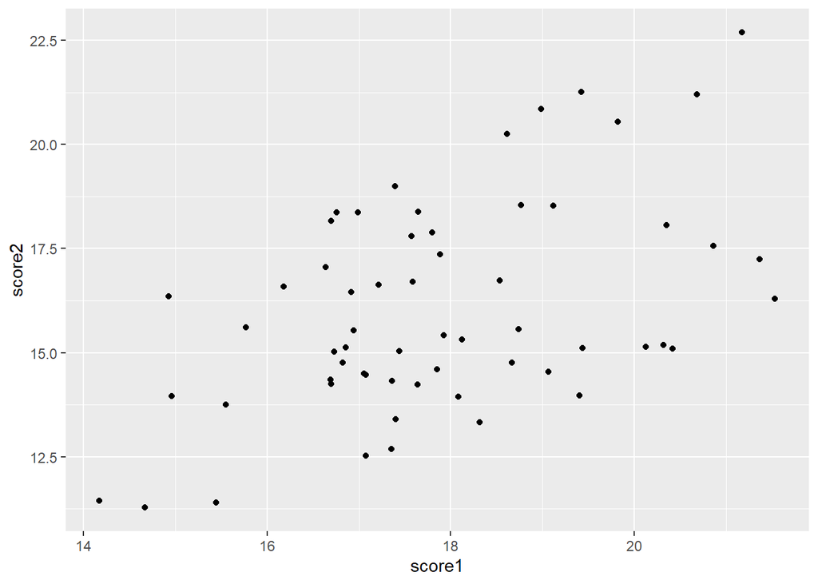

```r
df %>%
  ggplot(aes(x=score1, y=score2)) + geom_point()
```

#### 4.2

Continuing with the previous plot, colour the points based on gender.

Set the output figure width to 10 and height to 6.

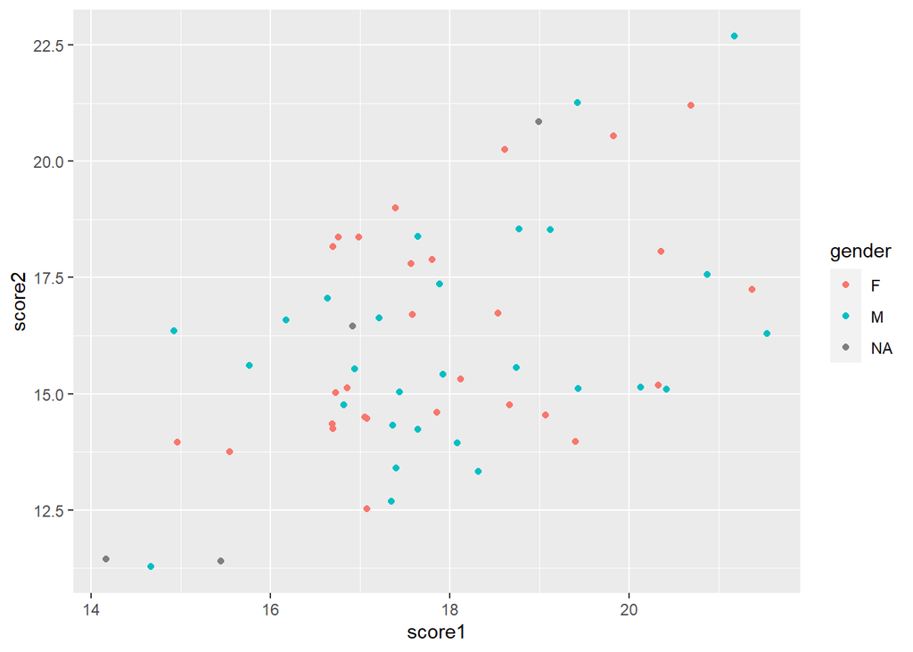

```r
df %>%
  ggplot(aes(x=score1, y=score2, color=gender), width = 10, height = 6) + geom_point()
```

# Exercise 5

#### 5.1

Add the author (your name) and date into the metadata section. Create a table of contents.

#### 5.2

Knit your document to HTML by changing `html_notebook` to `html_document` in the metadata, and pressing Knit.